# beatochess no. 06 (December 2024)

Beat Neuenschwander, email: neuenschwander.beat@gmail.com

# New studies

## Amatzia Avni 70-JT 2024

File: Neuenschwander-2024-Avni-70JT.pgn

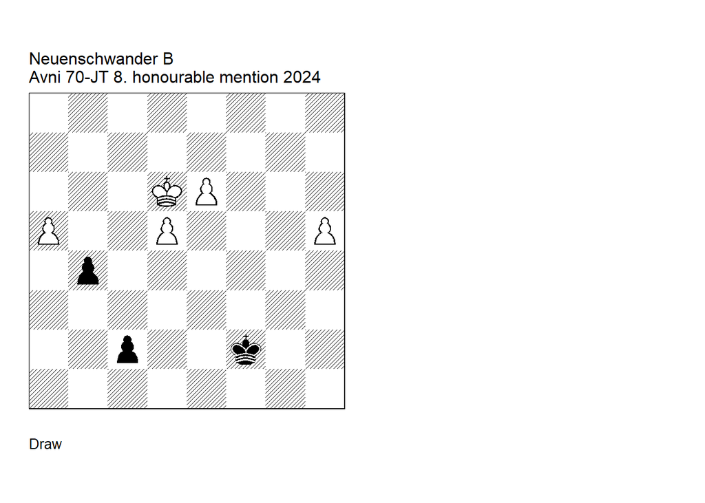

GBR: =0000.42d6f2 FEN: 8/8/3KP3/P2P3P/1p6/8/2p2k2/8 w - - 0 1

**1. e7 b3! Delayed queening is the most dangerous.** (1… c1=Q 2. e8=Q poses White no problems ) **2. h6! 2nd delayed queening.** (2. e8=Q? b2 3. Qf7+ Ke1! 4. Qe6+ Kd2! 5. a6 (5. Qh6+ Kd1 -+) 5… b1=Q! (5… c1=Q? 6. a7 b1=Q 7. a8=Q =) 6. a7 Qb6+ -+) **2… c1=Q** (2… b2 3. h7! b1=Q 4. h8=Q Qb4+ (4… c1=Q 5. Qd4+ = (5. e8=Q? Qb4+ -+) ) 5. Kd7 Qb5+ 6. Kd6 c1=Q 7. Qh2+ Kf3 8. Qh3+ Ke4 9. Qe6+ Kd4 10. Qe5+ Kd3 11. Qf5+ Kc3 12. Qc8+ Kb2 13. Qxc1+ Kxc1 14. Ke6 =) **3. e8=Q Qf4+** (3… b2 4. Qf7+! Ke1 5. h7 b1=Q 6. h8=Q =) (3… Qxh6+ 4. Qe6! Qf4+ 5. Kd7! =) **4. Kd7!** (4. Kc5? b2) **4… Qa4+ 5. Ke7** (5. Kd8 or ) **5… Qxe8+ 6. Kxe8 b2 7. d6! 3rd delayed queening.** (7. h7? b1=Q 8. h8=Q Qb8+ -+) **7… b1=Q 8. d7 Qg6+ 9. Ke7** (9. Kd8? Qxh6 10. Kc7 Qf4+ -+) **9… Qg5+ 10. Ke8 Qe5+ 11. Kd8!** (11. Kf7? Qd6 12. Ke8 Qe6+ -+) **11… Qxa5+ 12. Ke7** (12. Ke8 or ) **12… Qe5+ 13. Kf7** (13. Kf8? Qf6+ -+) **13… Qd6 14. h7! Qxd7+ 15. Kg8 1/2-1/2**.

> Amatzia Avni: “The repeated delayed promotion to a queen, by both black and white, is intriguing.”

## The Problemist 2023

File: Neuenschwander-2023-TheProblemist.pgn

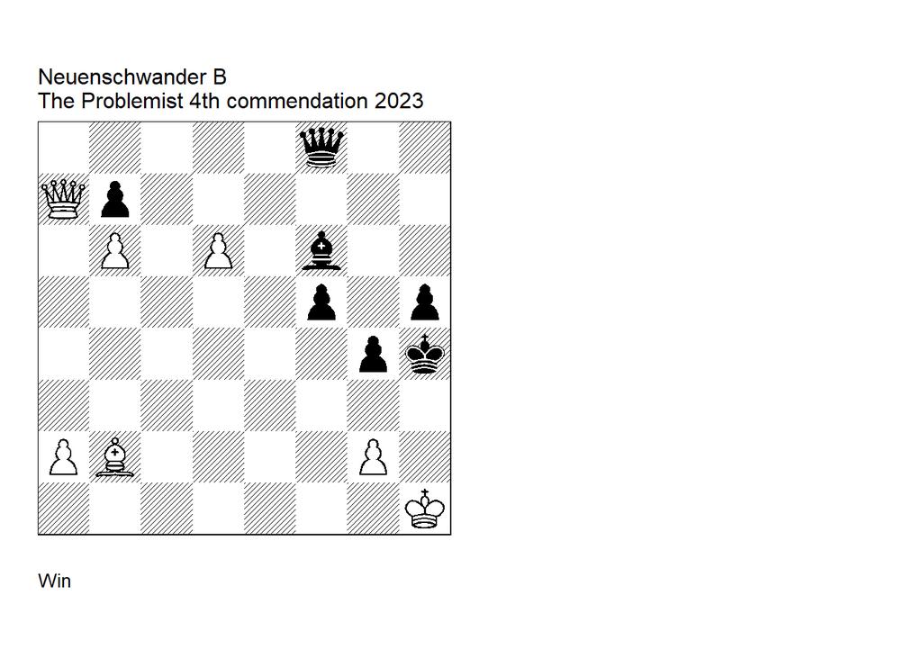

GBR: +4040.44h1h4 FEN: 5q2/Qp6/1P1P1b2/5p1p/6pk/8/PB4P1/7K w - - 0 1

**1. Qb8 Other ways to activate the badly placed white queen fail:** (1. Qxb7? Qxd6 2. Qc7 Qe6! 3. Qf4 (3. Bxf6+ Qxf6 4. b7 f4! 5. Qc5 (5. Qc1 Qb6 =) 5… Qa1+ 6. Qg1 Qb2 =) 3… Bxb2 4. Kh2 Qe2 5. b7 Be5 6. b8=Q Bxf4+ 7. Qxf4 Qxg2+ 8. Kxg2) (1. Qa3? Qd8! (1… Kg5? 2. d7! Qxa3 3. Bxa3 Bd8 (3… Kf4 4. Bd6+) 4. Be7+! Bxe7 5. a4) (1… Bxb2? 2. g3+! Kg5 3. Qxb2 Qxd6 4. Qg7+ Qg6 5. Qxg6+ Kxg6 6. a4) ) **1… Qxb8 2. Bxf6+ Kg3 3. d7 Qf4 The only way for counter-play. 4. Bh4+ Kxh4 5. d8=B+ Resurrection of the bishop.** ( 5. d8=Q+? Kg3 6. Qc7 Kh4! 7. Qxf4) **5… Kg3 6. Bc7 h4 7. Kg1** (7. a4? Kf2 8. Bxf4 g3 -/+) **1-0**.

## UAPA 2024

File: Neuenschwander-2024-UAPA-B1.pgn

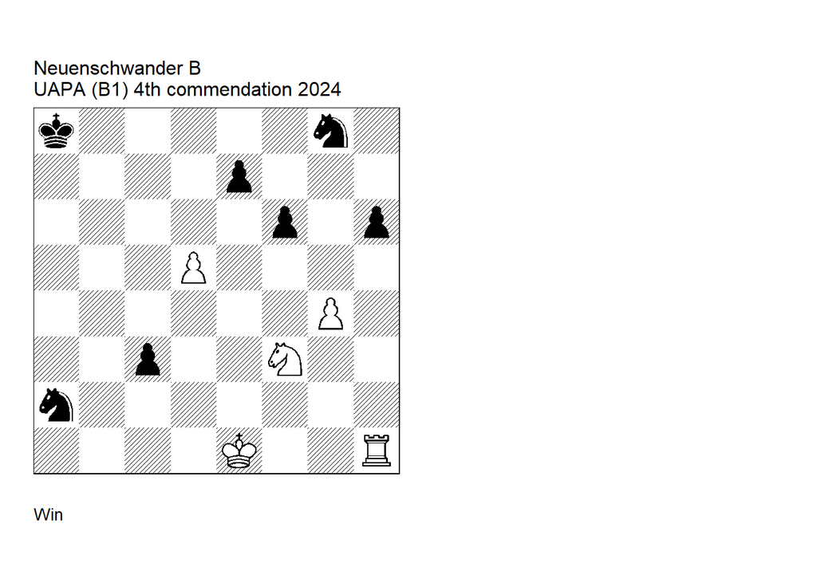

GBR: +0107.24e1a8 FEN: k5n1/4p3/5p1p/3P4/6P1/2p2N2/n7/4K2R w K - 0 1

**1. d6!** (1. Kd1? Nb4 2. Rh5 Kb7) (1. Nd4? Nb4 2. Rh5 Kb7) **1… exd6** (1… Kb7 leads to a technically lost endgame, e.g. 2. Nd4 exd6 3. Ke2 c2 (3… Ne7 4. Nc2) 4. Nxc2 Nc3+ 5. Kd3 Nd5 6. Ne3) **2. Rh2 Nb4** (2… Nc1 3. Kd1 Nd3 4. Ke2 =main line ) **3. Re2 Nd3+ 4. Kd1 Ne5 5. Nxe5 dxe5** (5… fxe5 6. Rf2 Kb7 7. Rf8 Ne7 8. Rf7) **6. g5!! Kb7** (6… fxg5 7. Rf2) (6… hxg5 7. Rh2) **7. g6! and wins, e.g. 7… Kc6 8. Ra2 Kd5 9. Ra8 Ne7 10. g7 1-0**.

> Eduard Eilazian: “An original geometric idea with a paradoxical breakthrough of the pawn and trapping the knight.”

File: Neuenschwander-2024-UAPA-B2.pgn

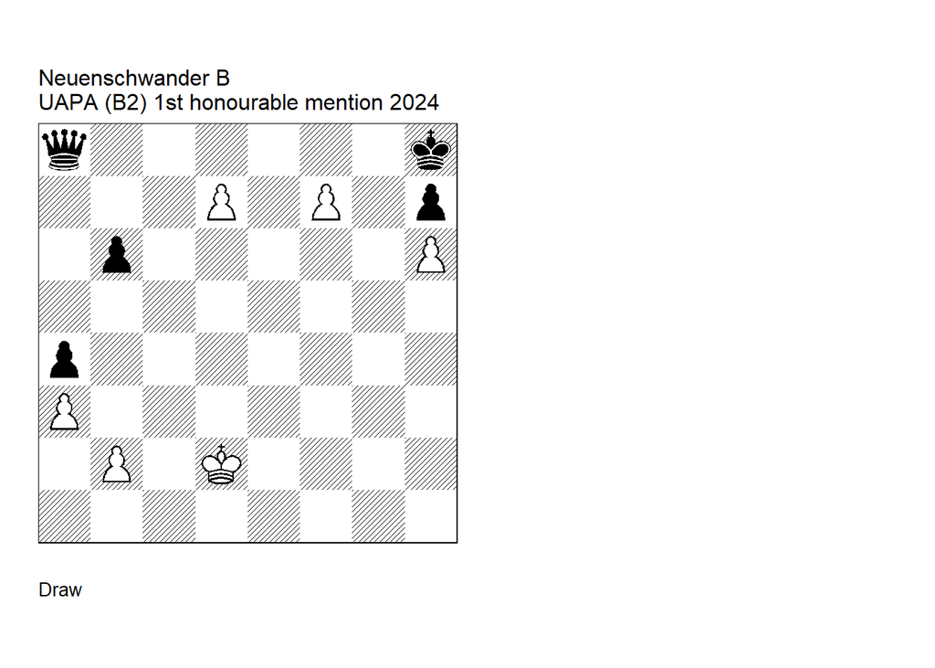

**1. b4!! A paradoxical move, giving Black a passed pawn in an already critical position.** (1. Kc1? Qc6+ 2. Kb1 Qg6+ 3. Ka1 Qf6 4. Kb1 b5 5. Kc2 (5. Ka1 Qf1+ 6. Ka2 Qxf7+) (5. Ka2 Qxf7+) (5. Kc1 Qxh6+) 5… Qg6+ 6. Kc3 Qf6+ 7. Kc2 b4 8. axb4 Qg6+ 9. Kc3 (9. Kd1 Qb1+?) 9… Qc6+) **1… axb3 2. a4!** (2. Kc3? Qf3+! 3. Kb2 Qf6+ 4. Kb1 Qf5+ 5. Ka1 Qe5+) **2… Qa5+** ( After 2… b2 3. Kc2 Qxa4+ 4. Kxb2 Black cannot win ) **3. Kd3!** (3. Kd1? Qh5+! 4. Kc1 Qxh6+) (3. Ke2? Qe5+! 4. Kd3 Qf6! 5. Kd2 Qxh6+) (3. Kc1 Qc3+ 4. Kd1 Qf6 ) **3… Qf5+** (3… Qd5+ 4. Kc3! Qe5+ 5. Kxb3 positional draw ) **4. Kc3! Qf6+ 5. Kd3! Qd6+ 6. Kc3! Qe7 7. Kb2! Qf6+ 8. Kb1!** (8. Ka3? b2 9. Ka2 Qxf7+) **8… b2** (8… Qd6 9. Kb2! Qe7 10. Kc3! (10. Kb1? Qf6!) 10… Qf6+ 11. Kd3! positional draw ) **9. Kc2!** (9. Ka2? Qxf7+) **9… Qf2+ 10. Kb1 Qf6 11. Kc2 positional draw 1/2-1/2**.

> Helmut Waelzel. “White king in the center or on the kingside would lose one of the pawns d7, f7, h6 with check, so it needs exile on the queenside. There, for reasons of Zugzwang also, squares b2 and a3 are needed, a plan that cannot be delayed. A shocking key! Astonishing, that Black can not make use neither of the passed pawn itself nor of squares c2 and a2 of this queen. White king is manoevering against black queen, including quiet moves and even Zugzwang (position after 5.Kd3! is one, with thematic try 5.Ke2?, position after 8.Kb1! would be another, apparently withoug try).”

## Problem Paradise 2024 (published)

File: Neuenschwander-2024-ProblemParadise108.pgn

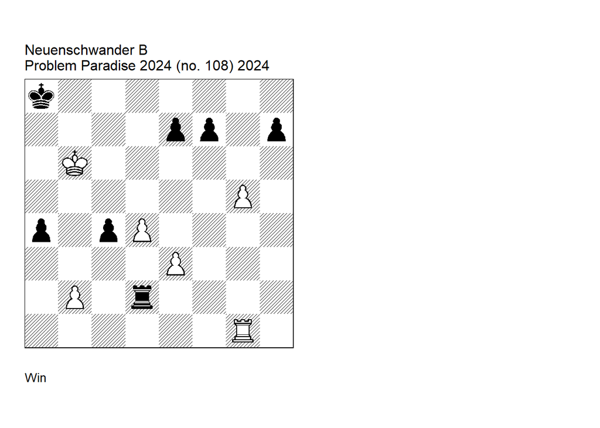

GBR: +0400.45b6a8 FEN: k7/4pp1p/1K6/6P1/p1pP4/4P3/1P1r4/6R1 w - - 0 1

**1. b4!** (1. b3? Rb2! =) **1… cxb3** (1… Rb2 2. b5 +-) **2. g6! b2** (2… fxg6 3. Rf1 +-) (2… hxg6 3. Rh1 +-) **3. gxf7** (3. gxh7? b1=Q+ 4. Rxb1 Rh2 5. Kc7 (5. Ra1 Kb8 =) 5… Ka7 =) (3. g7? b1=Q+ 4. Rxb1 Rg2 5. Kc7 (5. Ra1 Kb8 =) 5… Ka7 =) **3… b1=Q+ 4. Rxb1 Rf2 5. e4!** (5. Kc7? Rxf7 =) (5. d5? Rxf7) **5… Rxf7 6. e5 e6 7. Kc6 1-0**.

> Ryo Shiomi (editor): “Black has more material, but White is the one to play for a win with his supeior K. After the preparatory 1. b4!, 2. g6! is the breakthrough we want to see! After some resistance from Black, 5. e4! ~ 6. e5! is the practial way to win the R endgame.”

## EG (published)

File: Neuenschwander-2024-EG-238.pgn

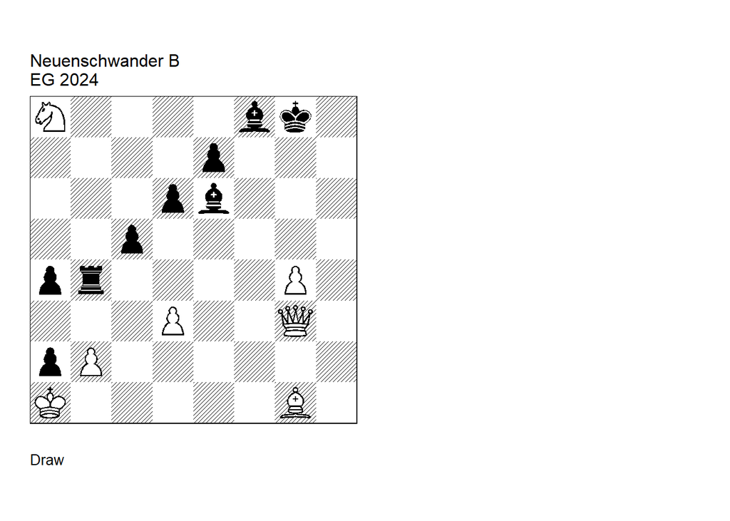

GBR: =1371.35a1g8 FEN: N4bk1/4p3/3pb3/2p5/pr4P1/3P2Q1/pP6/K5B1 w - - 1 1

**1. Qe3** (1. d4? Rb3! (1… a3? 2. Qxa3) 2. Qe1 (2. Qh4 a3) 2… Bf7 3. Nc7 a3) **1… Bf7** (1… Bb3 2. d4! Bg7 3. Qxe7) **2. Nc7** (2. d4? Bg7 3. Qxe7 (3. Nc7 Rxd4) 3… a3 4. Qd8+ Kh7 5. Qh4+ Bh6) **2… a3** (2… Bg7 3. Ne6 Rxb2 4. d4 Rb6 (4… Bxd4? 5. Qg5+ Kh7 6. Nxd4) (4… cxd4? 5. Qg5 Bxe6 6. Kxb2 d3+ 7. Bd4) 5. Kxa2) **3. b3! 1st opening of the long diagonal 3… Bxb3** (3… Rxb3 4. Ne6 Bg7+ 5. Kxa2) **4. Qg5+** (4. Ne6? Bg7+! 5. Nxg7 Bd5! (5… Bf7? 6. Ne6) 6. Qe1 Rb1+ 7. Qxb1 axb1=Q+ 8. Kxb1 Kxg7) **4… Bg7+ 5. Bd4! 1st closing of the long diagonal** (5. d4 Bc4) **5… Rxd4** (5… cxd4 6. Nd5) **6. Ne8 Rxg4+ 2nd opening 7. Nf6+! 2nd closing 7… exf6** (7… Kf7 /f8 8. Qxg4 Bxf6+ 9. d4 Bxd4+ 10. Qxd4 cxd4) **8. Qxg4 f5+ 3rd opening 9. d4! 3rd closing 9… fxg4 1/2-1/2**.

> Steffen Slumstrup Nielsen (editor): “With the newest study, Beat Neuenschwander seems to be exploring how much can happen down a diagonal in one single main line of a study.”

## Variantim (published)

File: Neuenschwander-2024-Variantim.pgn

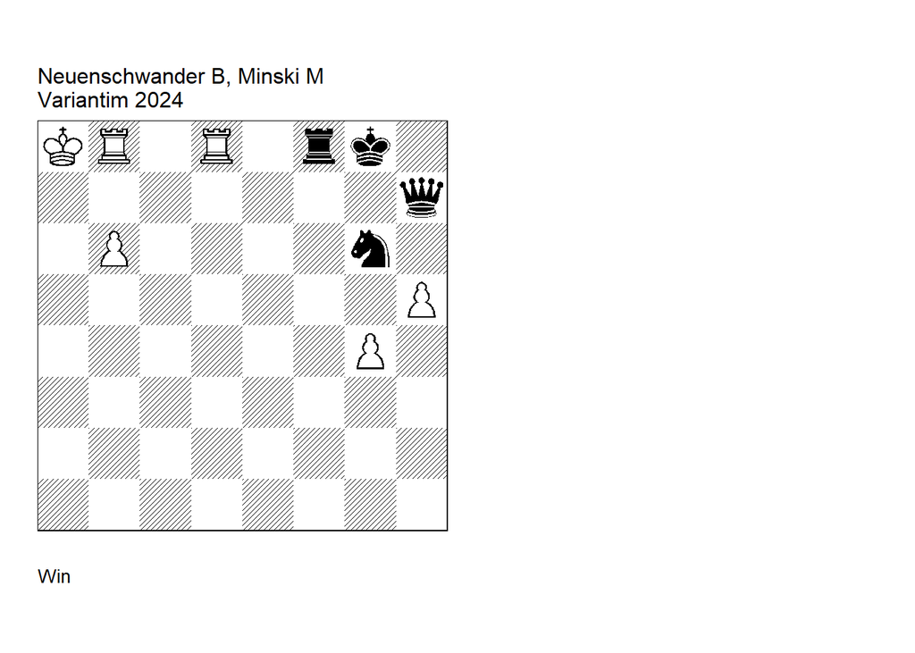

GBR: +3503.30a8g8 FEN: KR1R1rk1/7q/1P4n1/7P/6P1/8/8/8 w - - 0 1

**1. b7** (1. hxg6? Qh1+) (1. Rxf8+? Nxf8 2. b7 Qe4) **1… Qe7** (1… Qf7 main 1 2. Rxf8+ Nxf8 3. Rxf8+ Kxf8 (3… Qxf8+ see 3… Qxf8 below ) 4. b8=R+! (4. b8=Q+? thematic try 1 4… Kg7 5. Qb7 Kh8! 6. Qxf7 stalemate 1 ) 4… Kg7 5. Rb7) (1… Qg7 2. Rxf8+ Nxf8 3. Rxf8+ Kh7 (3… Qxf8+ see 3… Qxf8 below ) 4. Rf1!) **2. Rxf8+ Nxf8 3. Rxf8+ Qxf8+** (3… Kxf8 4. b8=R+! main 2 (4. b8=Q+? thematic try 2 4… Kg7! 5. Qb7 Kh6! 6. Qxe7 stalemate 2 ) 4… Kf7 5. Rb7) (3… Kh7 4. Rh8+! Kxh8 5. b8=R+!) **4. b8=R! Triple rook Phoenix to avoid stalemating of black king on h8, h7, and h6** (4. b8=Q? thematic try 3 4… Kh7! 5. Qxf8 stalemate 3 ) **1-0**.

## Phenix (published)

File: Neuenschwander-2024-Phenix.pgn

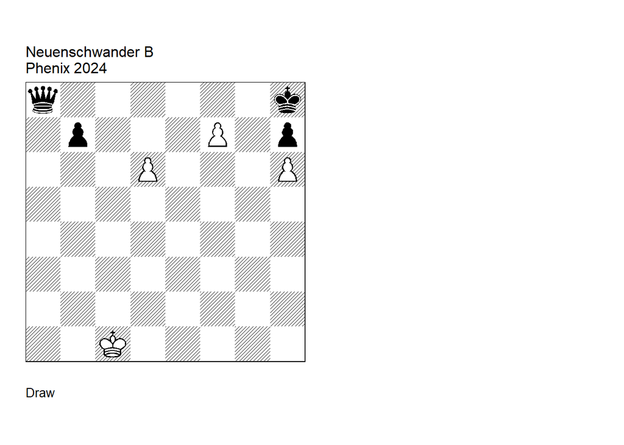

GBR: =3000.32c1h8 FEN: q6k/1p3P1p/3P3P/8/8/8/8/2K5 w - - 0 1

**1. Kb2!** (1. d7? Qa1+! 2. Kd2 (2. Kc2 Qf6 3. Kb1 b5! 4. Kc2 b4 5. Kb1 b3 -+) 2… Qf6 3. Kc2 b6!! (3… b5? 4. Kb1 b4 5. Kc2 =) 4. Kb1 b5 5. Kc2 b4 6. Kb1 b3 -+) (1. Kb1? Qd8! 2. d7 Qf6! 3. Kc2 b6!! -+) **1… Qd8 2. d7 Qf6+** (2… Qe7 3. Kc3! Qf6+ 4. Kb4! Qe7+ 5. Kc3! =) **3. Ka3!** (3. Kc2? b6! -+) (3. Kb1? b5! -+) **3… Qe7+ 4. Kb2 Qf6+ 5. Ka3 b5** (5… b6 6. Kb4 Qe7+ 7. Kc3 b5 8. Kc2 /Kb2= ) **6. Kb4 Qe7+ 7. Kc3** (7. Ka5? b4) **7… b4+ 8. Kb2** (8. Kc2? Qf6! 9. Kb1 b3 -+) **8… Qf6+** (8… Qd6 9. Kb3 /Kb1= ) **9. Kc2** (9. Kb1? b3 -+) **9… Qg6+ 10. Kb2 Qf6+ 11. Kc2 Qg6+** (11… b3+ 12. Kb1 /Kd3= ) **12. Kb2 positional draw 1/2-1/2**.

## Schach (published)

File: Neuenschwander-2024-Schach.pgn

I was inspired by a motive (Nxb5!!) from the game F.Svane - Rakotomaharavo (Germany-Madagaskar, round1, Chess Olympiade 2024): see YouTube video (time 5:18:20)

> https://www.youtube.com/live/fOf1tInefEI?si=4f9M4UMLK8TjB7tp

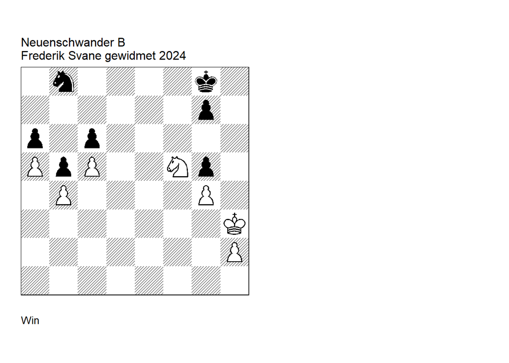

GBR: +0004.55h3g8 FEN: 1n4k1/6p1/p1p5/PpP2Np1/1P4P1/7K/7P/8 w - - 0 1

**1. Nd6!** (1. Kg3? Kf7! 2. Kf3 Nd7 3. Ke4 Kf6! 4. Nd6 g6) **1… g6** (1… Nd7 2. Nxb5!! Das “Svane” Motiv. 2… cxb5 3. c6) ( Schwarz hat kein Gegenspiel nach 1… Kf8 2. Ne4) **2. Kg2!** (2. Kg3? Nd7 3. Nxb5? funktioniert hier nicht: 3… cxb5 4. c6 Nf6) ( Knapp unzureichend ist 2. Ne4? Nd7 3. Nxg5 Ne5 4. Kg3 Nd3 5. Kf3 Nxb4 6. Ke4 Na2! 7. Kd4 (7. Kd3 Nb4+!) 7… Nc1! 8. Kc3 Ne2+ 9. Kd2 (9. Kd3 Nc1+!) 9… Nd4) **2… Kg7** (2… Nd7 3. Nxb5) **3. Ne4** (3. Kf3? Nd7!) **3… Nd7 4. Nxg5 Kf6 5. Nf3** (5. h4? Ne5 6. Kg3 Nd3) **5… Ke6 6. h4! Kd5 7. h5 gxh5 8. gxh5 Kc4 9. h6 Nf8 10. Ne5+ Kxb4 11. Nd7!** (11. Nxc6+? Kxc5 12. Nb8 b4) (11. Kg3? Nh7! (11… Kxc5? 12. Nd7+) (11… Kxa5 12. Nxc6+?) 12. Kf4 Kxc5 13. Kf5 b4 14. Kg6 b3 ( 14… Nf8+? 15. Kg7 Ne6+ 16. Kf7 Ng5+ 17. Kg6 Ne6 18. Nd7+ Kd6 19. h7) 15. Kxh7 Kd4!) **11… Nh7 12. Nb8! Kxc5** (12… Kxa5 13. Nxc6+) **13. Nxa6+ Kd6 14. Nb4 1-0**.

# Comments and revisions

## Studies by Mattison

### Studies in HHdbVI

Mattison in HHdbVI

| no | res.gbr.Kk | comments | year | source |
| --- | --- | --- | --- | --- |
| 1 | +0002.22f6h5 |  | 1911 | Rigasche Rundschau |
| 2 | +0301.33c1g5 | U3 | 1912 | Rigasche Rundschau |
| 3 | +0301.43c1g5 | (c) | 1912 | Rigasche Rundschau |
| 4 | =3107.10h1h8 |  | 1912 | Rigaer Tageblatt |
| 5 | =0107.11f6b5 |  | 1912 | Rigasche Rundschau |
| 6 | =0103.02e8h8 | U1 | 1913 | Rigaer Tageblatt#600 |
| 7 | +0301.23h4h7 | (m) | 1913 | Rigasche Rundschau |
| 8 | +0311.10e6b4 | U3 | 1913 | Rigaer Tageblatt |
| 9 | +0312.11e6b4 | (c) | 1913 | Rigaer Tageblatt |
| 10 | +0320.11d5b4 | (c) | 1913 | Rigaer Tageblatt |
| 11 | =0133.12b1h5 | U2 | 1913 | Rigaer Tageblatt |
| 12 | =0011.24a4e7 |  | 1913 | Rigaer Tageblatt |
| 13 | =0133.12b1h5 | (c) | 1913 | Rigaer Tageblatt |
| 14 | +0301.22h4h7 |  | 1913 | Rigasche Rundschau |
| 15 | =0002.04f6d8 |  | 1913 | Rigaer Tageblatt#582 |
| 16 | =0005.03f6d8 | (c) | 1913 | Rigaer Tageblatt#582 |
| 17 | =0005.03g6e8 | (v) U2 | 1913 | Rigaer Tageblatt#582 |
| 18 | +0012.13a2d5 | U3 | 1913 | Rigasche Zeitung#21 |
| 19 | +0012.24a2d5 | (c) | 1913 | Rigasche Zeitung#21 |
| 20 | =0110.14g2b5 |  | 1913 | Rigaer Tageblatt#591 |
| 21 | =0310.01d3f7 |  | 1913 | Rigasche Rundschau |
| 22 | =0103.12a8g1 |  | 1913 | Rigasche Zeitung#57 |
| 23 | =0103.02e8h8 | (c) | 1913 | Rigaer Tageblatt#600 |
| 24 | +0034.21h8d3 | (c) | 1914 | Rigaer Tageblatt |
| 25 | =0310.11f4a5 | (c) | 1914 | Rigasche Zeitung#10 |
| 26 | =0310.11f4a5 | (v) U2 | 1914 | Rigasche Zeitung#10 |
| 27 | =0310.11f4a5 | U1 | 1914 | Rigasche Zeitung#10 |
| 28 | =0310.11f4b4 | (v) | 1914 | Rigasche Zeitung#10 |
| 29 | +0031.11h2e8 | (v) | 1914 | Rigaer Tageblatt#612 |
| 30 | +0031.21h2e8 |  | 1914 | Rigaer Tageblatt#612 |

[output cut: 61 more lines]

### Mattison +0133.12h3a6 (1922). Correction

Date: 2024, October 22

File: Mattison1922.pgn

**Study no. 47** (Table 1)

The suspected cook by John Nunn is indeed a cook according to tablebase. The correction by Garcia is incorrect for the same reason: the Q-bn ending is lost. The additional black pawn on h4 gives black just enough counterplay.

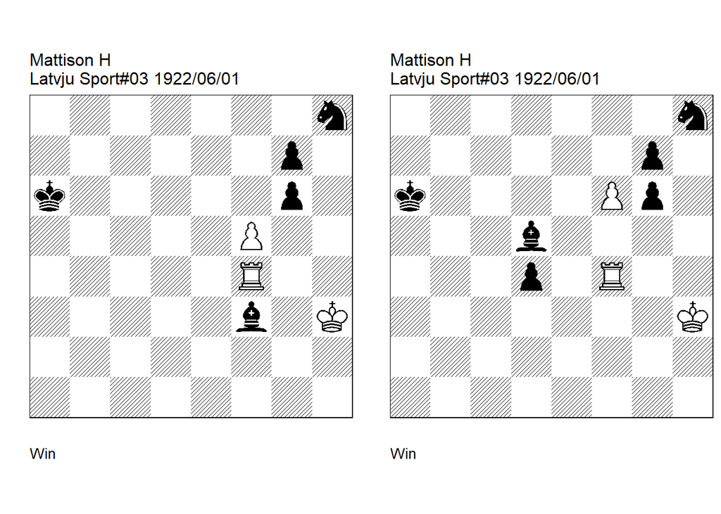

GBR: +0133.12h3a6 FEN: 7n/6p1/k5p1/5P2/5R2/5b1K/8/8 w - - 0 1

**Latvju Sport=11 . U2: Nunn=J Mattison’s Chess Endgame Studies 29 1987. 1. f6 Bd5** (1… gxf6 2. Rxf6+ Kb5 (2… Kb7 3. Rxf3 g5 4. Rf6 Kc7 5. Rh6 Nf7 6. Rh7) 3. Rxf3 g5 4. Rf6 Kc5 5. Kg4 Kd5 6. Kxg5 Ke5 7. Rf8) **2. fxg7 Nf7 3. Rd4** (3. Rg4? Kb7! (3… Ne5? 4. Rg5) (3… Be6? 4. Kh2! Ne5 5. Re4 Nf3+ 6. Kg3 Ng5 7. Rxe6+) 4. Rxg6 Ne5 5. Rg5 Be6+) (3. Rf5 gxf5 4. g8=Q Kb7! 5. Kg3! cook JN 5… Kc7 6. Kf4 Kd7 7. Qg7 Be6 8. Qf8 Kc6 9. Qe7 Kd5 10. Qc7) **3… Bb3!** (3… Ng5+ 4. Kg4) **4. Rd3 Bc4! 5. Rc3 Be6+** (5… Bf1+ main 6. Kh4 Nh6 7. Kg5 Ng8 8. Rc8 Ne7 9. Re8) (5… Bd5 main 6. Rc5 Be6+ (6… Bb3 7. g8=Q Ng5+ 8. Rxg5 Bxg8 9. Rxg6+ Kb7 10. Rxg8) 7. Kh2! (7. Kg2? Bc8) (7. Kh4? g5+ 8. Kg3 (8. Kh5 Kb6 9. Rf5 Bxf5 10. g8=Q Bg4+! 11. Kg6 Be6) 8… Kb6! 9. Rf5 Nd6) 7… Nd8 (7… Kb6 8. g8=Q Kxc5 9. Qxg6) 8. Rc8) **6. Kh4!** ( 6. Kh2? Ne5) (6. Kg3? Nh6) **6… Nh6** (6… g5+ main 7. Kg3! (7. Kh5? Nd8 8. Rc8 Bf7+ 9. Kxg5 Ne6+) 7… Nh6 8. Rc6+ Kb5 9. Rxe6 Nf5+ 10. Kg4 Nxg7 11. Re7) **7. Rc6+ Kb5 8. Rxe6 Nf5+ 9. Kg5 Nxg7 10. Re5+ Kc4** (10… Kc6 11. Kxg6 Kd6 12. Kf6) **11. Kxg6 Kd4 12. Kf6 1-0**.

GBR: +0133.13h3a6 FEN: 7n/6p1/k4Pp1/3b4/3p1R2/7K/8/8 w - - 0 1

**Latvju Sport=11 . correction: Garcia=M Estudios Artisticos de Ajedrez - VII-27 2012. U2: Van, der, Heijden=H HHdbV 76674 11-5-2013. 1. fxg7 Nf7 2. Rxd4** (2. Rf5! cook HH 2… gxf5 3. g8=Q Kb5 4. Kg3 d3 5. Kf2 Kb4 6. Qg6) **2… Bb3!** (2… Ng5+ 3. Kg4) **3. Rd3 Bc4! 4. Rc3 Be6+** (4… Bf1+ main 5. Kh4 Nh6 6. Kg5 Ng8 7. Rc8 Ne7 8. Re8) (4… Bd5 main 5. Rc5 Be6+ (5… Bb3 6. g8=Q Ng5+ 7. Rxg5 Bxg8 8. Rxg6+ Kb7 9. Rxg8) 6. Kh2! (6. Kg2? Bc8) (6. Kh4? g5+ 7. Kg3 (7. Kh5 Kb6 8. Rf5 Bxf5 9. g8=Q Bg4+! 10. Kg6 Be6) 7… Kb6! 8. Rf5 Nd6) 6… Nd8 (6… Kb6 7. g8=Q Kxc5 8. Qxg6) 7. Rc8) **5. Kh4!** (5. Kh2? Ne5) (5. Kg3? Nh6) **5… Nh6** (5… g5+ main 6. Kg3! (6. Kh5? Nd8 7. Rc8 Bf7+ 8. Kxg5 Ne6+) 6… Nh6 7. Rc6+ Kb5 8. Rxe6 Nf5+ 9. Kg4 Nxg7 10. Re7 ) **6. Rc6+ Kb5 7. Rxe6 Nf5+ 8. Kg5 Nxg7 9. Re5+ Kc4** (9… Kc6 10. Kxg6 Kd6 11. Kf6) **10. Kxg6 Kd4 11. Kf6 1-0**.

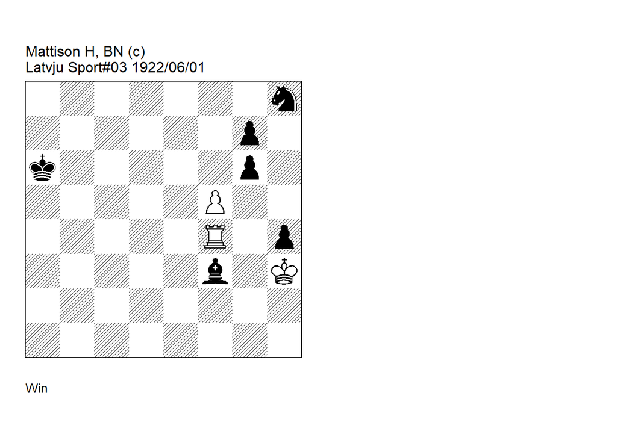

GBR: +0133.13h3a6 FEN: 7n/6p1/k5p1/5P2/5R1p/5b1K/8/8 w - - 0 1

**correction: Neuenschwander=B beatochess 22/10/2024. 1. f6 Bd5 2. fxg7 Nf7 3. Rd4** (3. Rf5? Be6! (3… gxf5? 4. g8=Q +-) 4. Kg2 (4. Kxh4 Nd6) (4. Kh2 Nh6) 4… h3+! (4… Bxf5? 5. g8=Q h3+ 6. Kg3 +- tablebase ) 5. Kg1 (5. Kh2 Nh6) 5… Bxf5 6. g8=Q Nd6 = tablebase ) **3… Bb3 4. Rd3 Bc4** (4… Be6+ 5. Kxh4) **5. Rc3 Bd5** (5… Be6+ 6. Kxh4 Nh6 7. Rc6+ Kb5 8. Rxe6 Nf5+ 9. Kg5 Nxg7 10. Re5+ Kc4 11. Kxg6) (5… Bf1+ 6. Kxh4 Nh6 7. Kg5 Ng8 8. Rc8 Ne7 9. Re8) **6. Rc5 Bb3 7. g8=Q Ng5+ 8. Rxg5 Bxg8 9. Rxg6+ 1-0**.

### Mattison =0103.02e8h8 (1913). Version

Date: 2024, October 28

File: Mattison1913.pgn

**Study no. 23** (Table 1)

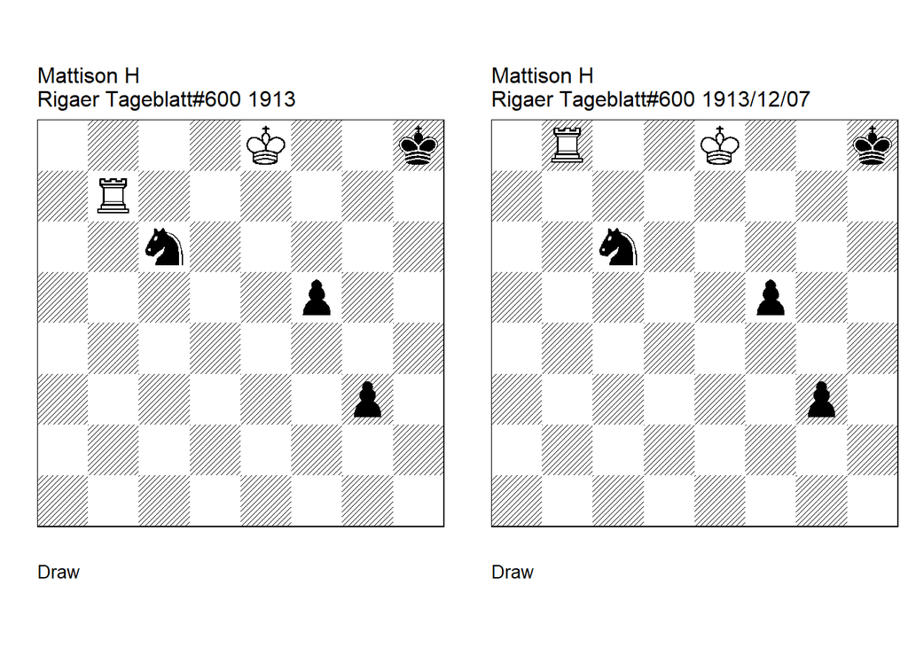

GBR: =0103.02e8h8 FEN: 4K2k/1R6/2n5/5p2/8/6p1/8/8 w - - 0 1

**also Kalender in Liv. Est. u Kurland 1914 7-12-1913. U1: Visokosov=A Shakhmatnaya Nedelya=45** (76) **11/2003. 1. Rb3!** (1. Kf8! cook AV 1… f4 2. Rg7! Ne5 3. Rg5! Kh7 4. Ke7! (4. Rg8? Kh6 5. Ke7 Kh5 6. Kf6 Ng4+ 7. Kf5 g2 8. Rg5+ Kh6 9. Rg6+ Kh7 10. Rxg4 f3) 4… Kh6 (4… Nf3 5. Rg4 Nh2 6. Rg5 f3 (6… Nf1 7. Kf6 f3 8. Rh5+ Kg8 9. Rg5+ Kf8 10. Ra5 Ke8 11. Ke6 Kd8 12. Kd6 Kc8 13. Kc6 Kb8 14. Rb5+ Ka7 15. Ra5+ Kb8 16. Rb5+) 7. Kf7! Kh6 8. Rxg3 f2 9. Rg6+ Kh5 10. Rf6) 5. Kf6) (1. Rb1? Kg7 2. Rg1 f4 3. Rf1 g2 4. Rxf4 Ne5 5. Rf5 Kh6) (1. Rb2? f4) **1… f4 2. Rf3!** (2. Rb5? Kh7! 3. Rg5 Kh6 4. Rg4 Ne5 5. Rxf4 g2) **2… g2** (2… Ne5 main 3. Rxf4 g2 4. Rf5 g1=Q 5. Rh5+ Kg7 6. Rg5+ Qxg5) **3. Rxf4 Ne5!** (3… g1=Q main 4. Rh4+ Kg7 5. Rg4+! Qxg4) **4. Rf5! g1=Q** (4… Nf3 5. Kf7) **5. Rh5+ Kg7 6. Rg5+! Qxg5 1/2-1/2**.

GBR: =0103.02e8h8 FEN: 1R2K2k/8/2n5/5p2/8/6p1/8/8 w - - 0 1

**correction: Visokosov=A Shakhmatnaya Nedelya=45** (76) **11/2003. 1. Rb3! f4! 2. Rf3!** (2. Rb5? Kh7! 3. Rg5 Kh6 4. Rg4 Ne5 5. Rxf4 g2) **2… g2 3. Rxf4 Ne5!** (3… g1=Q main 4. Rh4+ Kg7 5. Rg4+! Qxg4) **4. Rf5! g1=Q 5. Rh5+ Kg7 6. Rg5+! Qxg5 1/2-1/2**.

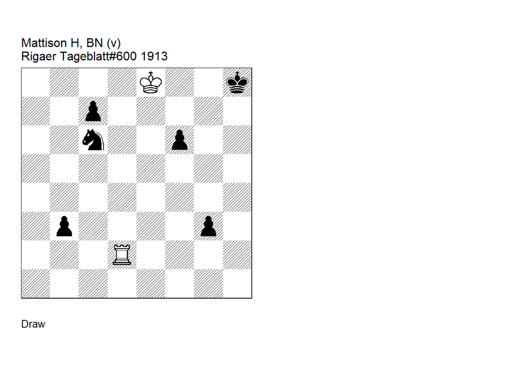

GBR: =0103.04e8h8 FEN: 4K2k/2p5/2n2p2/8/8/1p4p1/3R4/8 w - - 1 1

**version: Neuenschwander=B beatochess 28/10/2024. 1. Rg2** ( Try: 1. Rb2? Nd4 2. Kf7 c5 3. Rg2 Nf5 4. Kxf6 c4 5. Kxf5 c3 6. Kg6 b2 7. Rg1 Kg8) **1… b2 2. Rxb2 f5 3. Rb3 f4 4. Rf3 Ne5** (4… g2 main 5. Rxf4 g1=Q 6. Rh4+ Kg7 7. Rg4+ Qxg4) **5. Rxf4 g2 6. Rf5 g1=Q 7. Rh5+ Kg7 8. Rg5+ Qxg5 1/2-1/2**.

## Miscellaneous

### Gorgiev +0143.00f1h8 (1929). Correction

Date: 2024, November 7

File: Gorgiev1929.pgn

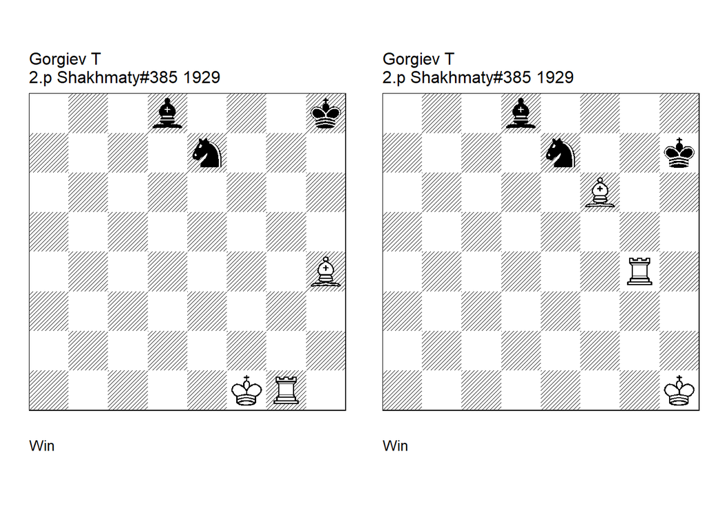

GBR: +0143.00f1h8 FEN: 3b3k/4n3/8/8/7B/8/8/5KR1 w - - 0 1

**Shakhmaty=4 Shakhmaty/4 4.p USSR Study Composition champ 1929 64=13-14 30-7-1931. U1 U2: Elkies=N EG=138 10/2000. 1. Bf6+** (1. Ke2! cook NE 1… Nc6 2. Bf2! Kh7 3. Kf3) **1… Kh7 2. Rg7+** (2. Ke2! cook NE ) **2… Kh6!** (2… Kh8 3. Rxe7+) **3. Rf7 Kg6!** (3… Nc6 4. Bxd8 Nxd8 5. Rd7 Ne6 6. Rd6) ( 3… Kh5 4. Bxe7 Kg6 5. Rf6+) **4. Rf8 Nc6! 5. Bxd8 Kg7! 6. Re8 Kf7! 7. Rh8 Kg7 8. Bf6+! Kxf6 9. Rh6+ Ke7 10. Rxc6 1-0**.

GBR: +0143.00h1h7 FEN: 3b4/4n2k/5B2/8/6R1/8/8/7K w - - 0 1

**Shakhmaty=4 Shakhmaty/4 4.p USSR Study Composition champ 1929 64=13-14 30-7-1931. correction: Problemist Ukraini=4** (26) **10-12/2010. 1. Rg7+ Kh6 2. Rf7! Kg6!** (2… Nc6 3. Bxd8 Nxd8 4. Rd7! Ne6 5. Rd6) **3. Rf8 Nc6! 4. Bxd8 Kg7! 5. Re8 Kf7! 6. Rh8 Kg7 7. Bf6+! Kxf6 8. Rh6+ 1-0**.

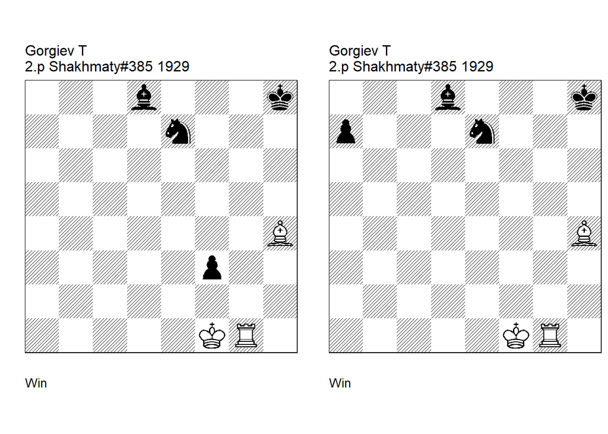

GBR: +0143.01f1h8 FEN: 3b3k/4n3/8/8/7B/5p2/8/5KR1 w - - 0 1

**Shakhmaty=4 Shakhmaty/4 4.p USSR Study Composition champ 1929 64=13-14 30-7-1931. correction: Byway=P British Chess Magazine=1 1/2015. 1. Bf6+ Kh7 2. Rg7+ Kh6 3. Rf7 Kg6 4. Rf8 Nc6 5. Bxd8 Kg7 6. Re8 Kf7 7. Rh8 Kg7 8. Bf6+ Kxf6 9. Rh6+ Kg7 10. Rxc6 1-0**.

GBR: +0143.01f1h8 FEN: 3b3k/p3n3/8/8/7B/8/8/5KR1 w - - 0 1

**Shakhmaty=4 Shakhmaty/4 4.p USSR Study Composition champ 1929 64=13-14 30-7-1931. correction: Garcia=M Estudios Artisticos de Ajedrez - VIII-74 2012. 1. Bf6+** (1. Ke2? Nc6 2. Bf2 Bb6) **1… Kh7 2. Rg7+** (2. Ke2? Nc6) **2… Kh6! 3. Rf7 Kg6!** (3… Nc6 4. Bxd8 Nxd8 5. Rd7 Ne6 6. Rd6) (3… Kh5 4. Bxe7 Kg6 5. Rf6+) **4. Rf8 Nc6! 5. Bxd8 Kg7! 6. Re8 Kf7! 7. Rh8 Kg7 8. Bf6+! Kxf6 9. Rh6+ Ke7 10. Rxc6 1-0**.

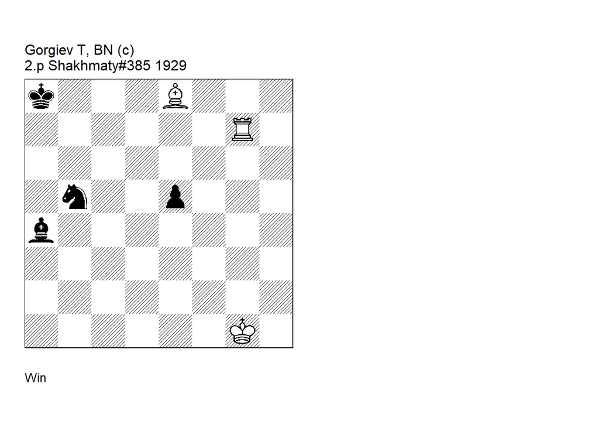

GBR: +0143.01g1a8 FEN: k3B3/6R1/8/1n2p3/b7/8/8/6K1 w - - 0 1

**correction: Neuenschwander=B beatochess 07/11/2024. 1. Bc6+** (1. Rg4? Bd1! 2. Rg8 Nc3!) (1. Rg2? Kb7! 2. Ra2 (2. Rg4 e4! 3. Rxe4 Nc3) 2… Nc3) (1. Kf2? Nc3!) **1… Kb8 2. Rb7+ Kc8 3. Rb6 Kc7 4. Ra6 Nc3 5. Bxa4 Kb7 6. Ra5 Kb6 7. Ra8 Kb7 8. Bc6+ Kxc6 9. Rc8+ 1-0**.

### Bazlov +0050.11d8e6 (1974). Correction

Date: 2024, November 7

File: Bazlov1974.pgn

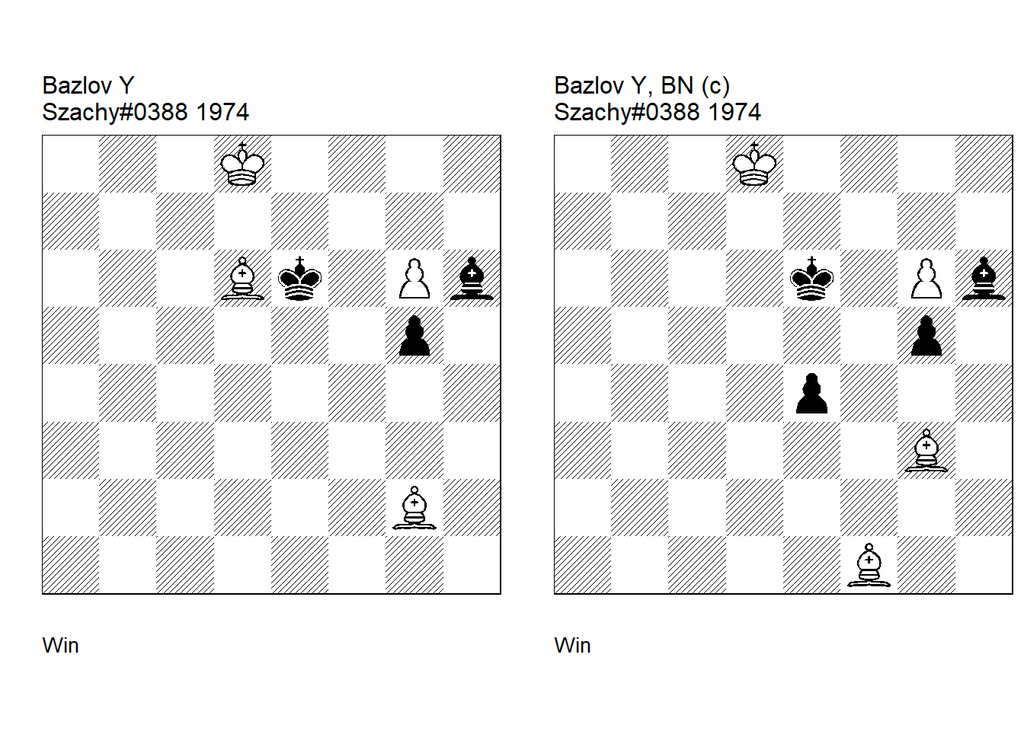

GBR: +0050.11d8e6 FEN: 3K4/8/3Bk1Pb/6p1/8/8/6B1/8 w - - 0 1

**Szachy=12** (336) **Szachy/12. U1: Szachy=5** (341) **5/1975. 1. Bg3** (1. Be7! cook 1… Kf5 2. Ke8 Kxg6 3. Be4+ Kh5 (3… Kg7 4. Bf8+) 4. Kf7 g4 (4… Kg4 5. Kg6) 5. Bg6 ) **1… Kf5! 2. Ke7 Kxg6 3. Be4+ Kh5!** (3… Kg7 4. Be5+ Kg8 5. Bd5+ Kh7 6. Kf7) **4. Kf7 Kg4** (4… g4 5. Bg6+ Kg5 6. Be1) **5. Bd6! Kh5 6. Be7 g4 7. Bg6 1-0**.

GBR: +0050.12d8e6 FEN: 3K4/8/4k1Pb/6p1/4p3/6B1/8/5B2 w - - 0 1

**correction: Neuenschwander=B beatochess 07/11/2024. 1. Bg2 Kf5 2. Ke7 Kxg6 3. Bxe4+ Kh5 4. Kf7 Kg4** (4… g4 5. Bg6+ Kg5 6. Be1) **5. Bd6!** (5. Bc7? Kh3 6. Kg6 Bf8) **5… Kh5 6. Be7 g4** (6… Kg4 7. Kg6) **7. Bg6 1-0**.

### Asaba +3100.33d8a8 (1974). Correction

Date: 2024, November 7

File: Asaba1974a.pgn

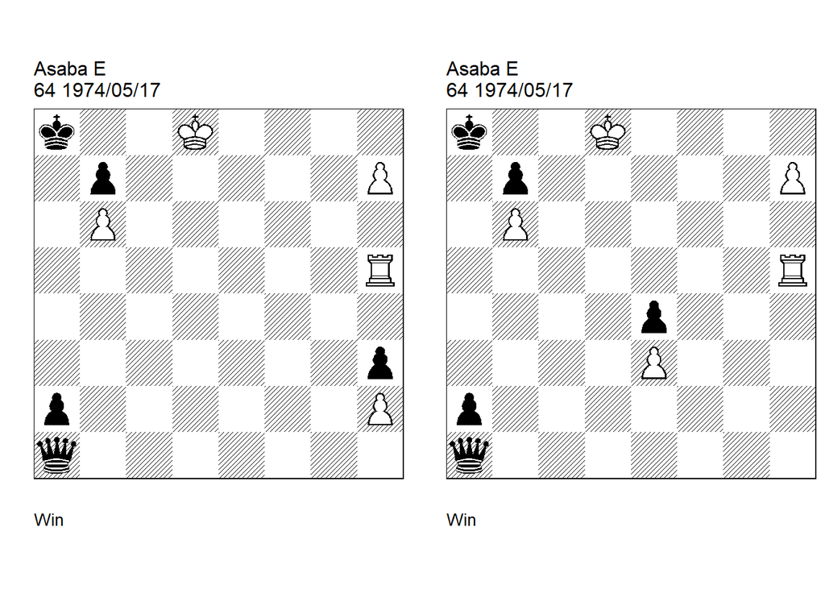

GBR: +3100.33d8a8 FEN: k2K4/1p5P/1P6/7R/8/7p/p6P/q7 w - - 0 1

**64=20** (307) **after Joseph=D d8a7 1922. U3: Ustimuk=G 64=43 1974. 1. h8=Q Qxh8+ 2. Rxh8 a1=Q 3. Rg8!** (3. Re8? Qg7 4. Kc8 Qe7!) **3… Qa2 4. Rf8 Qa3** (4… Qxh2! cook GU ) **5. Ke8! Kb8 6. Kf7+ Qxf8+ 7. Kxf8 Kc8 8. Ke7 Kb8 9. Kd7 Ka8 10. Ke6 Kb8 11. Kf5 Kc8 12. Kg4 Kd7 13. Kxh3 1-0**.

GBR: +3100.33d8a8 FEN: k2K4/1p5P/1P6/7R/4p3/4P3/p7/q7 w - - 0 1

**64=20** (307) **after Joseph=D d8a7 1922. correction: Asaba=E 64=43 1974. U2: Ulrichsen=J HHdbIV 41677 6-7-2006. 1. h8=Q Qxh8+ 2. Rxh8 a1=Q 3. Rg8! Qa2 4. Rf8 Qa3 5. Ke8! Kb8 6. Kf7+ Qxf8+ 7. Kxf8 Kc8 8. Ke7 Kb8 9. Kd7!** (9. Ke6! cook JU 9… Kc8 10. Ke5 Kd7 11. Kd5 Ke7 12. Kxe4) (9. Kd6! cook JU ) (9. Kf6! cook JU ) **9… Ka8 10. Kd6 Kb8 11. Kd5 Kc8 12. Kxe4 Kd7 13. Kd5 1-0**.

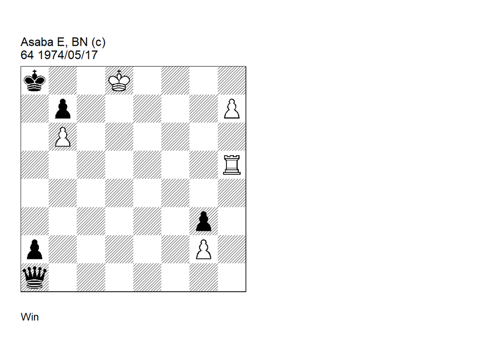

GBR: +3100.33d8a8 FEN: k2K4/1p5P/1P6/7R/8/6p1/p5P1/q7 w - - 0 1

**correction: Neuenschwander=B beatochess 07/11/2024. 1. h8=Q Qxh8+ 2. Rxh8 a1=Q 3. Rg8 Qa2 4. Rf8 Qa3** (4… Qf2 5. Ke7+) **5. Ke8 Kb8 6. Kf7+ Qxf8+ 7. Kxf8 Kc8 8. Ke7 Kb8 9. Kd7 1-0**.

### Maksimovskikh =0400.24b2a7 (1974). Correction

Date: 2024, November 7

File: Maksimovskikh1974.pgn

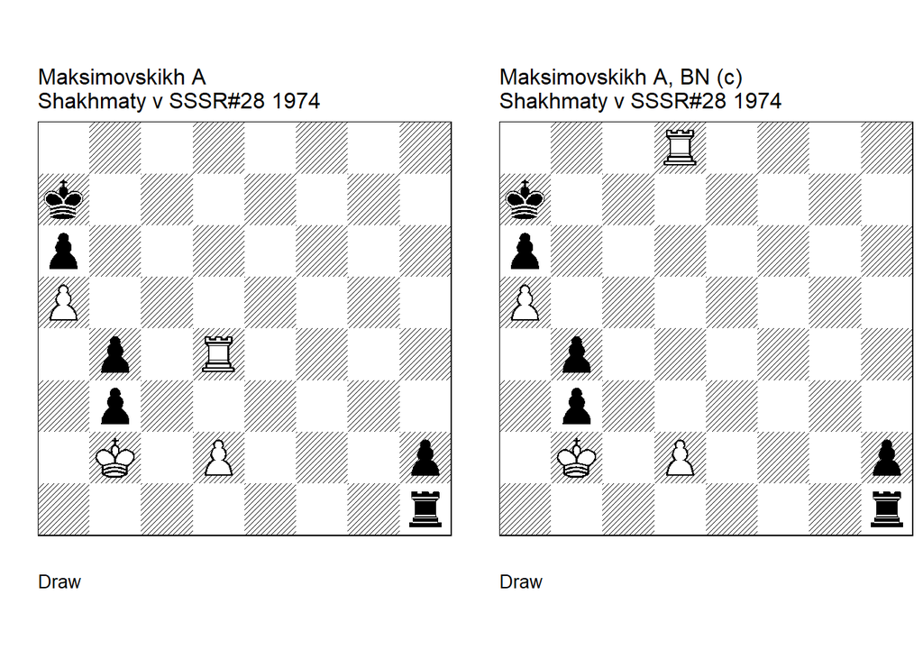

GBR: =0400.24b2a7 FEN: 8/k7/p7/P7/1p1R4/1p6/1K1P3p/7r w - - 0 1

**Shakhmaty v SSSR/7. 1. Rd7+!** (1. Rh4? Kb7 2. Rh6 Kc7) **1… Kb8** (1… Ka8 2. Rh7 Kb8 3. d4! Kc8 4. d5 Kd8 5. d6) **2. Rh7 Kc8 3. d3! Kd8 4. d4 Ke8 5. d5 Kf8 6. d6 Ke8** (6… Kg8 7. d7! Kxh7 8. d8=Q Rb1+ 9. Kxb1 h1=Q+ 10. Kb2) **7. Re7+! Kd8 8. Rh7 Kc8 9. Rc7+ Kd8 10. Rh7 Ke8 11. Re7+ Kf8 12. Rh7 1/2-1/2**.

GBR: =0400.24b2a7 FEN: 3R4/k7/p7/P7/1p6/1p6/1K1P3p/7r w - - 3 1

**correction: Neuenschwander=B beatochess 07/11/2024. 1. Rd7+ Kb8** (1… Ka8 2. Rh7 Kb8 3. d4!) **2. Rh7 Kc8 3. d3! Kd8 4. d4 Ke8 5. d5 Kf8 6. d6 Ke8 7. Re7+ Kd8 8. Rh7 Kc8 9. Rc7+ Kd8 1/2-1/2**.

Date: 2024, November 7

File: Asaba1974b.pgn

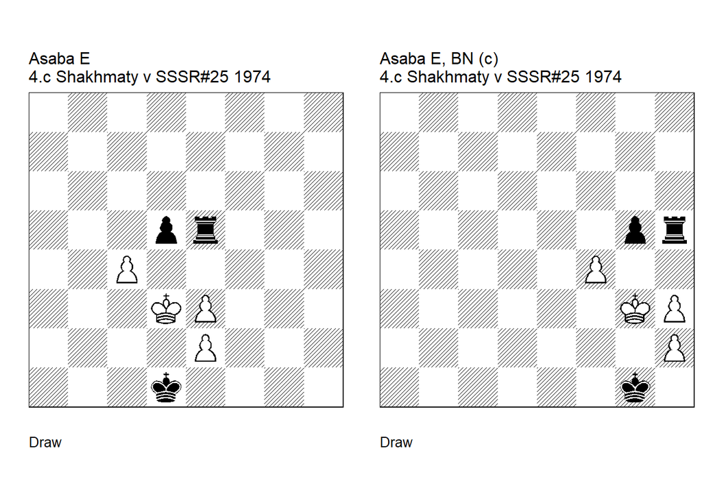

GBR: =0300.31d3d1 FEN: 8/8/8/3pr3/2P5/3KP3/4P3/3k4 w - - 0 1

**Shakhmaty v SSSR/7** (EG 02758) **. U3: Bourzutschky=M Konoval=Y EG=191 1/2013. 1. c5!** (1. Kd4? dxc4!) **1… Re4! 2. c6 Rc4** (2… Re6! cook MB/YK 3. c7 Rc6 4. Kd4) **3. e4! Rxe4 4. c7 Rc4** (4… Re8 main 5. Kd4 Rc8 6. Kxd5 Rxc7 7. e4) **5. e4! Rxc7 6. exd5 1/2-1/2**.

GBR: =0300.31g3g1 FEN: 8/8/8/6pr/5P2/6KP/7P/6k1 w - - 0 1

**correction: Neuenschwander=B beatochess 07/11/2024. 1. f5 Rh4 2. f6 Rf4** (2… Rh6 3. Kg4 Rxf6 4. Kxg5 Rf8 5. h4 Kxh2 6. h5) **3. h4 Rxh4 4. f7 Rf4** (4… Rh8 5. Kg4 Rf8 6. Kxg5 Rxf7 7. h4) **5. h4 Rxf7 6. hxg5 1/2-1/2**.

### Belikov =0037.31h1h7 (1974). Correction

Date: 2024, November 18

File: Belikov1974.pgn

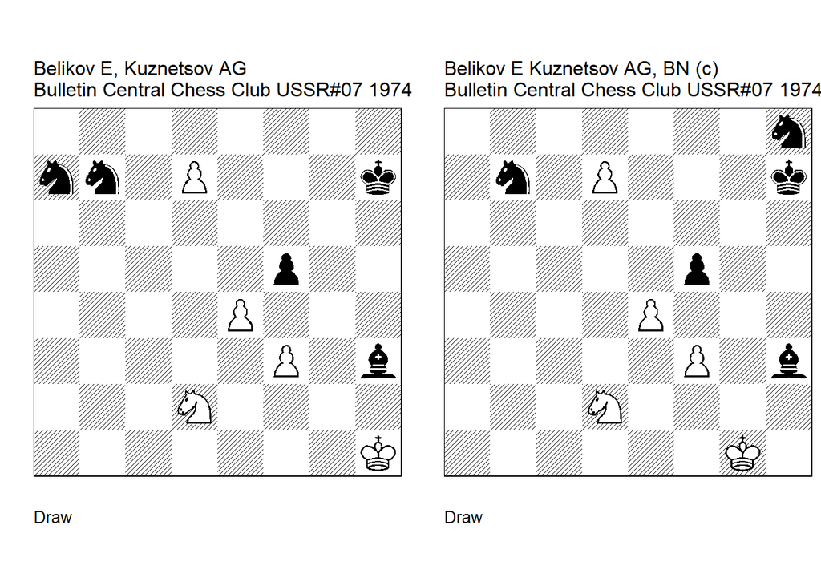

GBR: =0037.31h1h7 FEN: 8/nn1P3k/8/5p2/4P3/5P1b/3N4/7K w - - 0 1

**Bulletin Central Chess Club USSR/2. U3: Pogosyants=E Bulletin Central Chess Club USSR 1974. 1. Kh2 fxe4! 2. Nxe4! Bf1! 3. Kg1 Be2! 4. Kf2 Bd1!** ( 4… Bb5! cook EP 5. Nd6! Nd8 6. Nxb5 Nxb5 7. f4! Nd6 8. f5 Ne4+! 9. Ke3 Nf6! 10. Kd4 Nf7!) **5. Ke1 Bc2! 6. Kd2 Bb1! 7. Kc1 Ba2! 8. Kb2 1/2-1/2**.

GBR: =0037.31g1h7 FEN: 7n/1n1P3k/8/5p2/4P3/5P1b/3N4/6K1 w - - 0 1

**correction: Neuenschwander=B beatochess 18/11/2024 1. Kh2 fxe4 2. Nxe4 Bf1 3. Kg1 Be2 4. Kf2 Bd1 5. Ke1 Bc2 6. Kd2 Bb1 7. Kc1 Ba2 8. Kb2 1/2-1/2**.

Date: 2024, November 18

File: Bakay1954.pgn

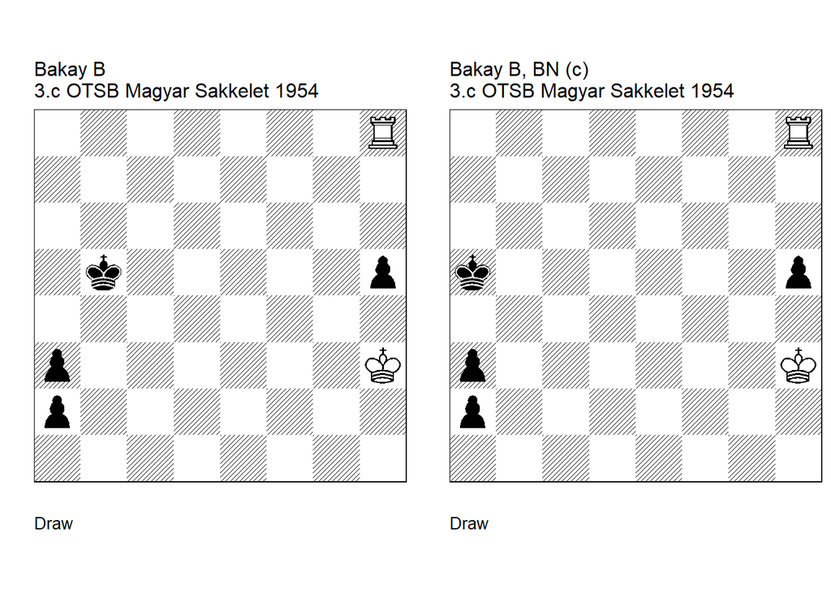

GBR: =0100.03h3b5 FEN: 7R/8/8/1k5p/8/p6K/p7/8 w - - 0 1

**Magyar Sakkelet/12 6/7.p Hungarian champ 1953-1955 Magyar Sakkelet/2 1956. U2= U3: Haworth=G Bleicher=E HHdbIV 27111 1-11-2009 U2: Van, der, Heijden=H HHdbIV 27111 27-12-2009. 1. Rb8+ Kc4 2. Rc8+ Kd3 3. Rd8+** (3. Rc1! cook HH ) **3… Ke2 4. Re8+ Kf1 5. Rf8+ Kg1 6. Re8!** (6. Rg8+! cook GH/EB ) **6… a1=Q** (6… a1=R! cook GH/EB ) **7. Re1+ Qxe1 1/2-1/2**.

GBR: =0100.03h3a5 FEN: 7R/8/8/k6p/8/p6K/p7/8 w - - 0 1

### Chekhover =3010.20a7f5 (1954). Correction

Date: 2024, November 20

File: Chekhover1954.pgn

Placing the bK on f4 corrects the study; see the comment after 5. Kb6. The other changes give White more possibilities to go wrong in the first move.

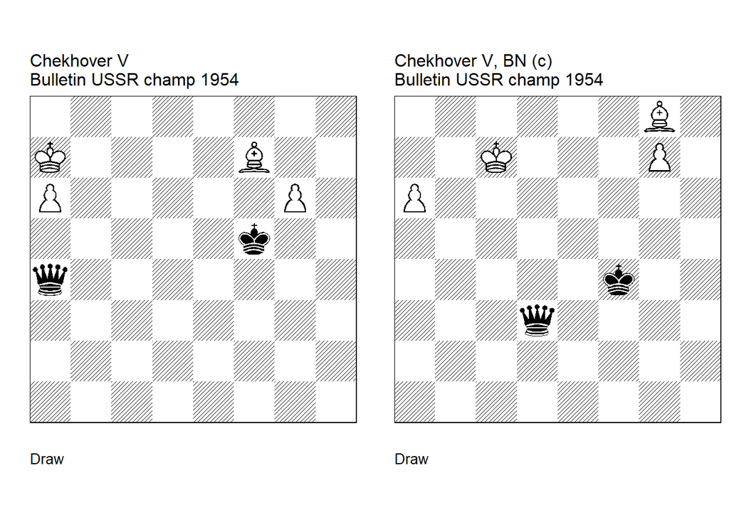

GBR: =3010.20a7f5 FEN: 8/K4B2/P5P1/5k2/q7/8/8/8 w - - 0 1

**U2: Conrady=H HHdbIII 41580 1-4-2005. 1. g7! Qd4+** (1… Qd7+ 2. Kb8 Qxf7 3. a7) **2. Kb7 Qxg7** (2… Qb2+ main 3. Kc8! (3. Kc7? Qxg7 4. a7 Qe5+) 3… Qxg7 4. a7 Qf8+ (4… Qc3+ main 5. Bc4! (5. Kb7? Qb4+) 5… Qa5 eg 6. Kb7) (4… Qg2 main 5. Bd5! (5. Kb8? Qb2+ 6. Bb3 Qe5+) 5… Qxd5 6. Kb8) 5. Be8! (5. Kb7? Qb4+) 5… Qc5+ eg 6. Kb7) **3. a7 Qb2+ 4. Bb3!** ( 4. Kc7? Qa3 5. Kb7 Qb4+ 6. Kc7 Qa5+ 7. Kb7 Qb5+ 8. Kc7 Qa6 9. Kb8 Qb6+) (4. Ka6? Qg2 5. Kb6 Ke5 6. Be8 Kd6) **4… Qg7+ 5. Bf7!** (5. Kb6! cook HC ) **5… Qg2+ 6. Bd5!** (6. Kb8? Qb2+ 7. Bb3 Qe5+) **1/2-1/2**.

GBR: =3010.20c7f4 FEN: 6B1/2K3P1/P7/8/5k2/3q4/8/8 w - - 0 1

**correction: Neuenschwander=B beatochess 20/11/2024. 1. Bf7!** (1. Be6? Qc3+ ) (1. Bh7? Qc3+) (1. a7? Qa6) **1… Qc3+ 2. Kb7 Qxg7** (2… Qb2+ main 3. Kc8! (3. Kc7? Qxg7 4. a7 Qe5+) 3… Qxg7 4. a7 Qf8+ (4… Qc3+ main 5. Bc4! (5. Kb7? Qb4+) 5… Qa5 eg 6. Kb7) (4… Qg2 main 5. Bd5! (5. Kb8? Qb2+ 6. Bb3 Qe5+) 5… Qxd5 6. Kb8) 5. Be8! (5. Kb7? Qb4+) 5… Qc5+ eg 6. Kb7) **3. a7 Qb2+ 4. Bb3! Qg7+ 5. Bf7!** (5. Kb6? Qd4+ 6. Ka6 (6. Kb7 Qb4+ 7. Kc7 Qc5+ 8. Kb7 Qb5+ 9. Kc7 Qa6 10. Kb8 Qb6+) 6… Qe4 Note that with the bK on f5, 7. Bc2 would draw here! ) **5… Qb2+ 6. Bb3 Qg7+ 7. Bf7 Qg2+ 8. Bd5! 1/2-1/2**.

### Herbstman =0403.11g4g8 (1925). Correction

Date: 2024, November 24

File: Herbstman1925.pgn

The duals on moves 1 and 2 can be avoided easily.

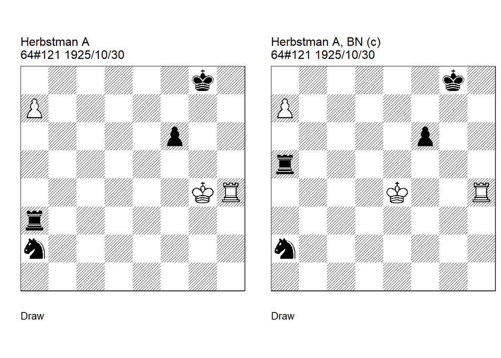

GBR: =0403.11g4g8 FEN: 6k1/P7/5p2/8/6KR/r7/n7/8 w - - 0 1

**64=20 .** (U2) **: 64=15-16 30-8-1926. 1. Kf5** (1. a8=Q+ Rxa8 2. Kf5) **1… Kg7 2. Rg4+** (2. a8=Q! minor dual ) **2… Kf7 3. a8=Q Rxa8 4. Ra4 Rxa4 1/2-1/2**.

GBR: =0403.11e4g8 FEN: 6k1/P7/5p2/r7/4K2R/8/n7/8 w - - 0 1

**correction: Neuenschwander=B beatochess 24/11/2024. 1. a8=Q+ Rxa8 2. Kf5 Kg7 3. Rg4+ Kf7 4. Ra4 Rxa4 1/2-1/2**.

### Kozakov +0440.33f8f6 (1925). Cook

Date: 2024, November 25

File: Kozakov1925.pgn

**1. a8=Q!** cooks the study.

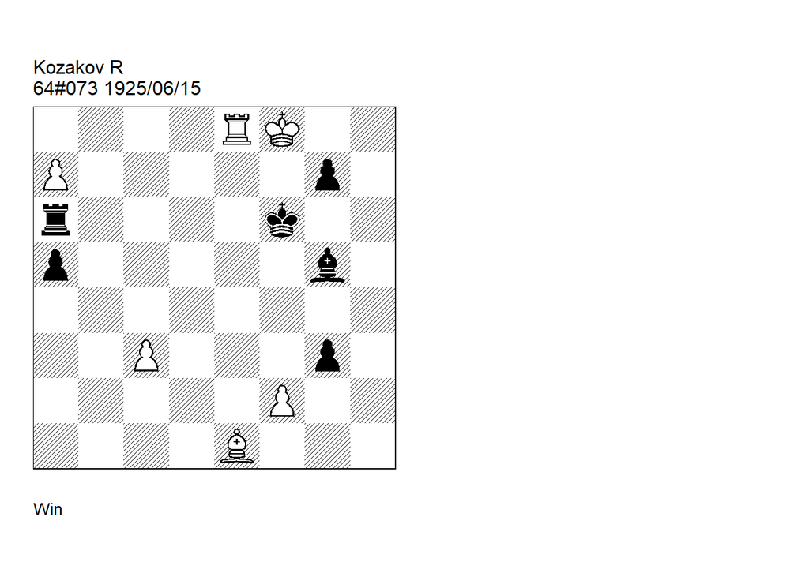

GBR: +0440.33f8f6 FEN: 4RK2/P5p1/r4k2/p5b1/8/2P3p1/5P2/4B3 w - - 0 1

**64=11. U1: Neuenschwander=B beatohess 25/11/2024 . 1. f4** (1. a8=Q! cook BN 1… Rxa8 2. Rxa8 g2 3. Ra6+ Kf5 4. Rxa5+ Kg6 5. Rxg5+ Kxg5 6. f4+) **1… Bxf4!** (1… Rxa7 2. fxg5+) (1… Bh4 2. a8=Q) **2. a8=Q Bd6+ 3. Kg8 Rxa8 4. Rxa8 g2 5. Bf2 Bh2 6. Ra6+ 1-0**.

### Levman +0011.12e2c2 (1925). Correction

Date: 2024, November 25

File: Levman1925b.pgn

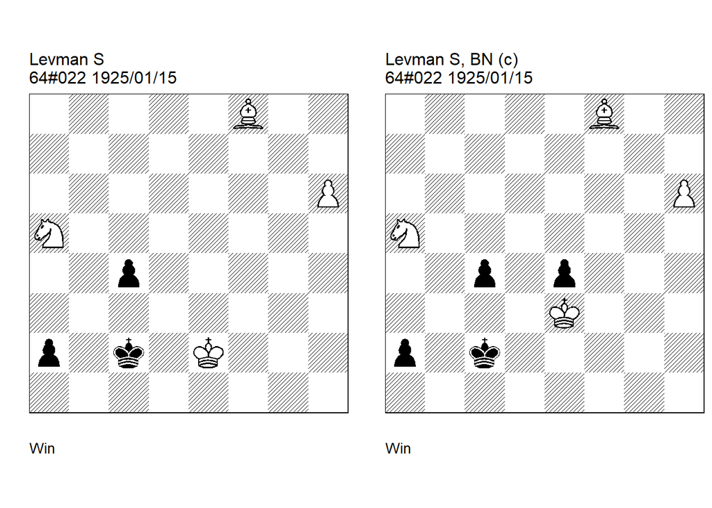

GBR: +0011.12e2c2 FEN: 5B2/8/7P/N7/2p5/8/p1k1K3/8 w - - 0 1

**64=1 . U2: Garcia=M HHdbV 74514 24-9-2011. 1. Bg7 c3 2. Nb3!** (2. Bxc3 Kxc3 3. h7 a1=Q 4. h8=Q+ (4. h8=B+ Kb4 5. Bxa1 Kxa5) 4… Kc2 5. Qxa1 (5. Qh7+! cook MG 5… Kc3 6. Qg7+ Kc2 7. Qg6+ Kc3 8. Qf6+ Kc2 9. Qf5+ Kc3 10. Qc5+ Kb2 11. Nc4+) ) **2… Kxb3 3. Bxc3 Kxc3 4. h7 a1=Q 5. h8=Q+ Kb3 6. Qxa1 1-0**.

GBR: +0011.13e3c2 FEN: 5B2/8/7P/N7/2p1p3/4K3/p1k5/8 w - - 0 1

**correction: Neuenschwander=B beatochess 25/11/2024. 1. Bg7 c3 2. Nb3!** (2. Bxc3? Kxc3 3. h7 a1=Q 4. h8=Q+ Kc2 5. Qxa1 (5. Qh2+ Kb1) ) **2… Kxb3 3. Bxc3 Kxc3 4. h7 a1=Q 5. h8=Q+ 1-0**.

### Levman +0314.21b7d1 (1925). Cook, Correction

Date: 2024, November 25

File: Levman1925a.pgn

**1… Rc5!** cooks the study.

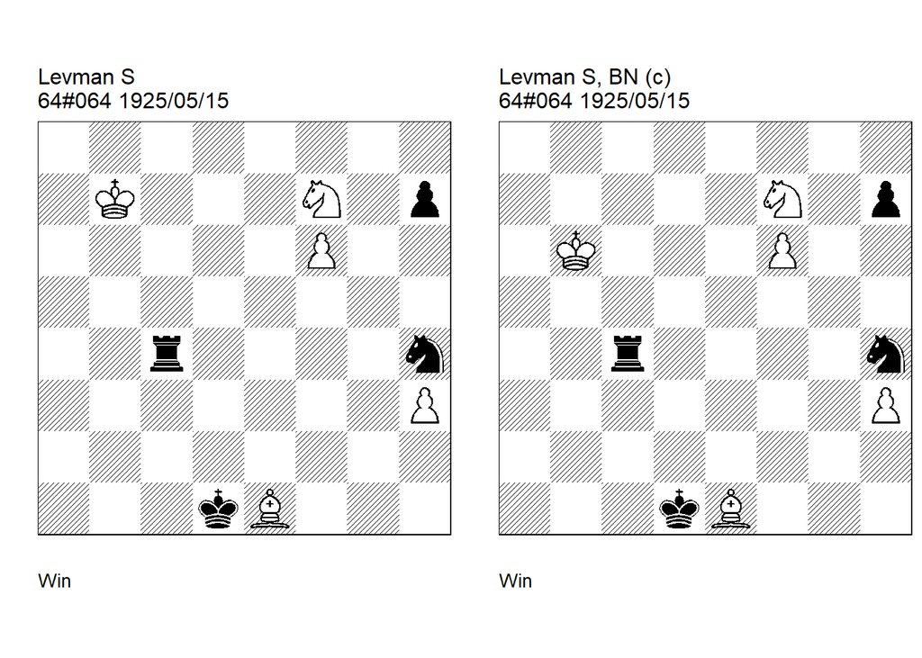

GBR: +0314.21b7d1 FEN: 8/1K3N1p/5P2/8/2r4n/7P/8/3kB3 w - - 0 1

**64=9 U3: Neuenschwander=B beatochess 25/11/2024 . 1. Ne5 Rf4** (1… Rc5! cook BN 2. f7 Ng6 3. Nxg6 Rf5 4. f8=Q Rxf8 5. Nxf8 Kxe1 =) **2. Bxh4 Rxh4 3. Ng4 Rh5 4. f7 Rf5 5. Ne3+ Ke2 6. Nxf5 1-0**.

GBR: +0314.21b6d1 FEN: 8/5N1p/1K3P2/8/2r4n/7P/8/3kB3 w - - 0 1

**correction: Neuenschwander=B beatochess 25/11/2024. 1. Ne5 Rf4 2. Bxh4 Rxh4 3. Ng4 Rh5 4. f7 Rf5 5. Ne3+ 1-0**.

### Lerner +3141.34h1g5 (1925). Cook, Correction

Date: 2024, November 26

File: Lerner1925a.pgn

Lerner’s correction fails (due to 1.Rc6! or 1.Re7!) but can be saved by placing the wB on d1.

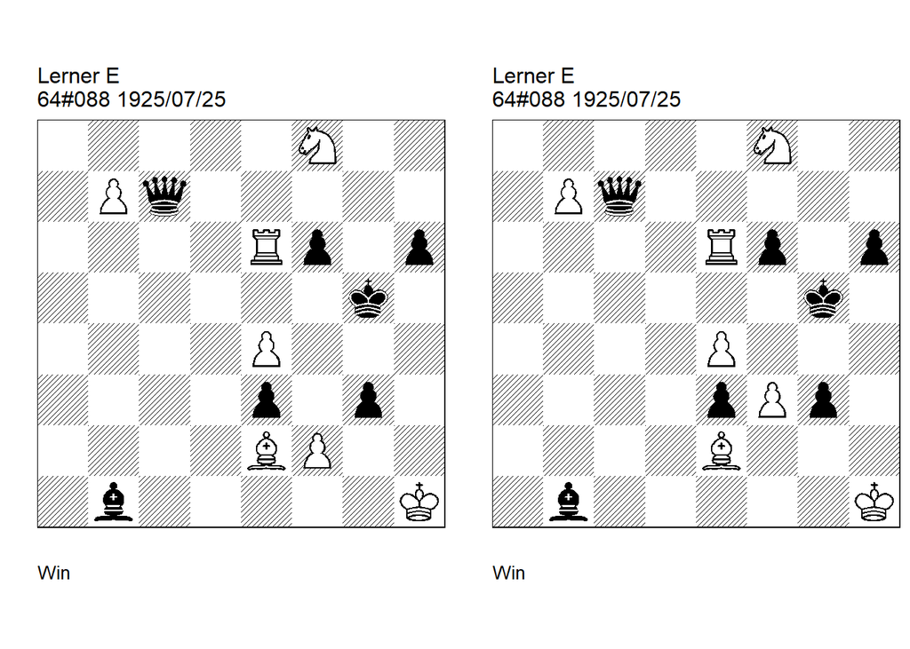

GBR: +3141.34h1g5 FEN: 5N2/1Pq5/4Rp1p/6k1/4P3/4p1p1/4BP2/1b5K w - - 0 1

**64=13 . U3: Grigoriev=N 64=21 15-11-1925. 1. Re5+ Qxe5** (1… fxe5! cook NG 2. Ne6+ Kh4 3. Nxc7 exf2) **2. f4+ Kxf4** (2… Qxf4 main 3. Ne6+ Kh4 4. Nxf4 Bxe4+ 5. Ng2+) **3. Ng6+ Kg5 4. Nxe5 Bxe4+ 5. Nf3+ 1-0**.

GBR: +3141.34h1g5 FEN: 5N2/1Pq5/4Rp1p/6k1/4P3/4pPp1/4B3/1b5K w - - 0 1

**64=13 . correction: Lerner=E Pravda 039 13-2-1927. U1: Neuenschwander=B beatochess 26/11/2024. 1. Re5+** (1. Rc6! cook BN ) (1. Re7! cook BN ) **1… Qxe5** (1… fxe5 2. Ne6+ Kh4 3. Nxc7) **2. f4+ Kxf4** (2… Qxf4 main 3. Ne6+ Kh4 4. Nxf4 Bxe4+ 5. Ng2+) **3. Ng6+ Kg5 4. Nxe5 Bxe4+ 5. Nf3+ 1-0**.

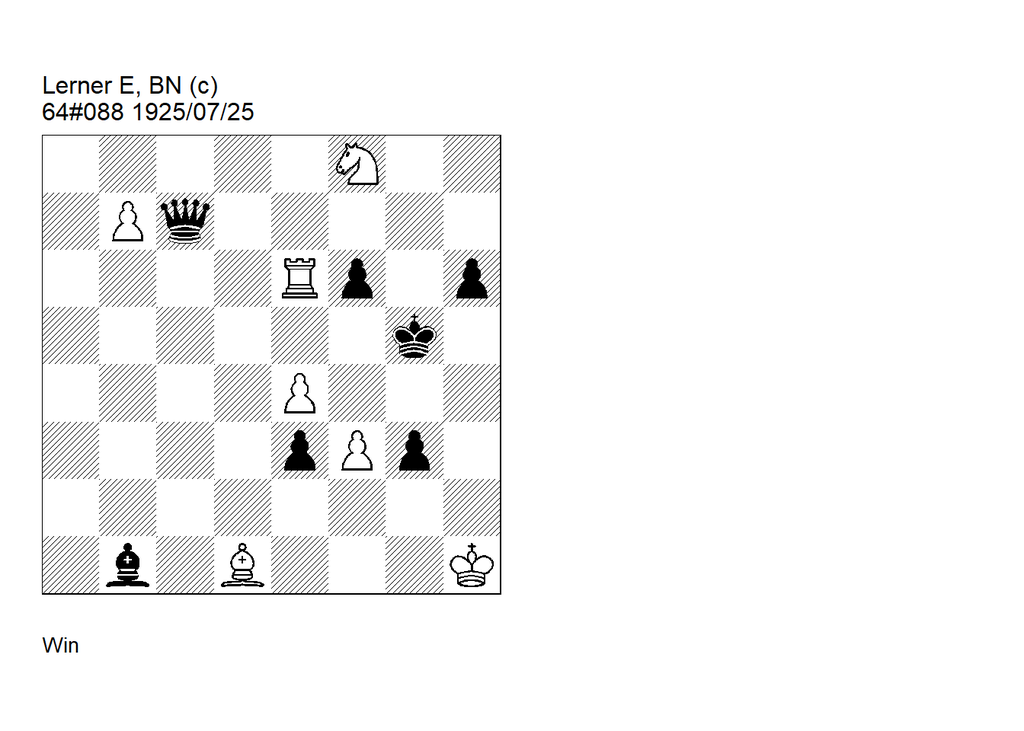

GBR: +3141.34h1g5 FEN: 5N2/1Pq5/4Rp1p/6k1/4P3/4pPp1/8/1b1B3K w - - 0 1

**correction: Neuenschwander=B beatochess 26/11/2024. 1. Re5+** (1. Rc6? e2! -+) **1… Qxe5 2. f4+ Kxf4** (2… Qxf4 main 3. Ne6+ Kh4 4. Nxf4 Bxe4+ 5. Ng2+) **3. Ng6+ Kg5 4. Nxe5 Bxe4+ 5. Nf3+ 1-0**.

### Fedotov +0031.21g7b4 (1954). Cook

Date: 2024, November 26

File: Fedotov1954.pgn

**2. Kf7!** cooks the study.

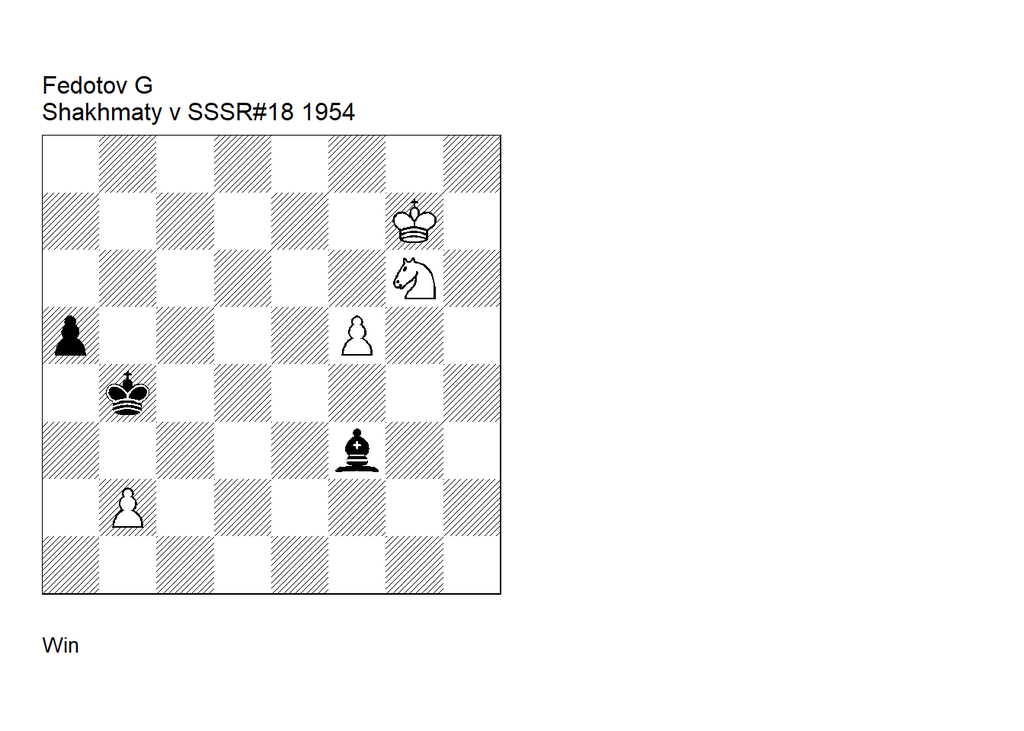

GBR: +0031.21g7b4 FEN: 8/6K1/6N1/p4P2/1k6/5b2/1P6/8 w - - 0 1

**Shakhmaty v SSSR/5.** (U2) **: Shakhmaty v SSSR/10 1954 U2: Neuenschwander=B beatochess 26/11/2024. 1. Nf4 Bd1 2. Nd5+** (2. f6? Bb3 3. Nd3+ Kb5 4. Kf8 Ba2 5. Ke7 a4 6. Nf4 Bg8) (2. Kf7! cook BN 2… Kb3 (2… Bb3+ 3. Ne6) 3. f6 Kxb2 4. Ke6) **2… Kb3 3. f6 Bh5 4. Nf4 Kxb2!** (4… Be8 5. Kf8 Bb5 6. Ke7 Bc4 7. Ne6) **5. Nxh5 a4 6. Nf4!** (6. f7? a3 7. f8=Q a2) **6… a3 7. Nd3+ Kc3 8. Nb4!** (8. f7! minor dual ) **8… Kxb4 9. f7 a2 10. f8=Q+ 1-0**.

### Herbstman +0040.22d2a4 (1925). Cook

Date: 2024, November 26

File: Herbstman1925b.pgn

**3. Kc5!** cooks the study.

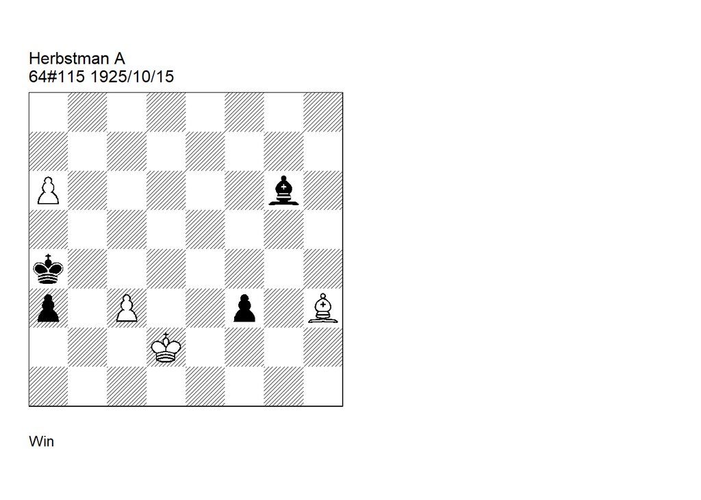

GBR: +0040.22d2a4 FEN: 8/8/P5b1/8/k7/p1P2p1B/3K4/8 w - - 0 1

**64=19 .U2: Neuenschwander=B beatochess 26/11/2024. 1. Ke3! Bf7 2. Kd4 Be8 3. a7** (3. Kc5! cook BN 3… Bg6 4. Kd5) **3… Bc6 4. Bd7! Bxd7 5. a8=Q+ 1-0**.